# Big Data & Policing

**HW 3**

This Python Notebook includes solution to the Part 1 of the HW3.

Created by **Saksham Gupta (20161090)**

```python
import os
from PIL import Image, ExifTags
import matplotlib.pyplot as plt
import pandas as pd
import datetime
from math import pi
import cv2
import sys
```

```python
def most_frequent(List):
    try:
        return max(set(List), key = List.count)
    except:
        return "No name"

def Average(lst):
    return sum(lst) / len(lst)
```

# Question 1

```python
path = "Isis Admin's Hacked Phones"
manufacturer ={}
for root, dirs, files in os.walk(path):
    for name in files:
        if name.endswith(("jpeg")) or name.endswith(("jpg")):
            a=root
            a+="/"
            a+=name
            temp = root.split('/')[:3]
            phone = temp[0] +"/"+ temp[1] +"/"+ temp[2]
            try:
                img = Image.open(str(a))
            except:
                continue
            try:
                exif = { ExifTags.TAGS[k]: v for k, v in img._getexif().items() if k in ExifTags.TAGS }
            except AttributeError:
                pass
            try:
                b=exif['Make']
            except:
                continue
            b=b.upper()
            if phone in manufacturer.keys():
                manufacturer[phone].append(b.strip('\x00'))
            else:
                manufacturer[phone] = []
                manufacturer[phone].append(b.strip('\x00'))
for key,values in manufacturer.items():
    manufacturer[key] = most_frequent(values)
df = pd.DataFrame({'mobile':manufacturer})
df['mobile'].value_counts(ascending=True)
```

```
MOBIISTAR          1
LG ELECTRONICS     1
JP BROTHERS        1
SONY               1
SAMSUNG           20
Name: mobile, dtype: int64
```

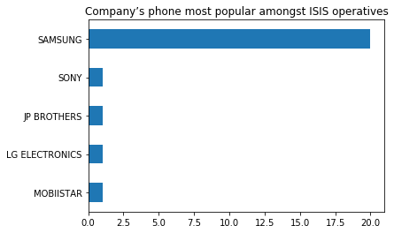

```python
_ = df['mobile'].value_counts(ascending=True).plot(kind='barh', title='Company’s phone most popular amongst ISIS operatives')
```

As we can see from the above bar graph **Samsung** is the most common phone among ISIS operatives.

# Question 2

```python
path = "Isis Admin's Hacked Phones"
outgoing ={}
count = 0
count_call = []
for root, dirs, files in os.walk(path):
    for name in files:
        if name.startswith(("Calllog Dump")):
            a=root
            a+="/"
            a+= name
            file =a
            file_rows = []
            with open(file) as f:
                for index, line in enumerate(f):
                    file_rows.append(line)
            f.close()

            for i,line in enumerate(file_rows):
                if 'OUTGOING' in line:
                    number = file_rows[i-3].strip('Number	: ').strip()
                    name = file_rows[i-2].strip('Name	: ').strip()
                    count_call.append(number)
                    if number in outgoing.keys():
                        outgoing[number].append(name)
                    else:
                        outgoing[number] = []
                        outgoing[number].append(name)
                else:
                    continue

df = pd.DataFrame({'call':count_call})
print (df['call'].value_counts(ascending=True))
```

```
+22796905013          1
0923753525            1
06472222              1
770507                1
+963933275784         1
0936132712            1
0247401456            1
+61291579615          1
10661188              1
0925143311            1
0926596704            1
032880086             1
0933913522            1
555518                1
0659384293            1
1204068741920856      1
*#21*                 1
#0599735104           1
0994509780            1
0935504857            1
770763116             1
580                   1
+218924629786         1
0927222242            1
0923120906            1
771767111             1
0675645842            1
0778631015            1
166                   1
0490587800            1
                   ...
+917780848045        63
0995222689           68
+919797407796        70
+963949369410        73
+963988739617        74
+919149409044        74
0932932555           75
0486794445           77
0996899813           79
+917889625367        84
0997493485           85
774145372            86
+32493858238         87
+8801780336699       91
+917006254848        91
+917006348792       102
+61432705893        110
+919906408233       114
0951567420          131
+963967139250       176
+963997421993       176
+919622095007       183
7780848045          184
7006348792          192
123                 215
+917780809871       237
0933637039          250
+32486794445        257
00966550326715      264
0997421993          300
Name: call, Length: 819, dtype: int64
```

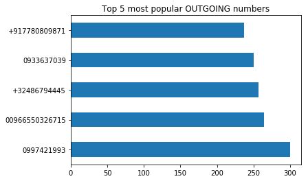

```python
_ = df['call'].value_counts(ascending=True).nlargest(5).plot(kind='barh', title='Top 5 most popular OUTGOING numbers')
```

```python
print(most_frequent(outgoing['+917780809871']))
print(most_frequent(outgoing['0933637039']))
print(most_frequent(outgoing['+32486794445']))
print(most_frequent(outgoing['00966550326715'].remove('null')))
print(most_frequent(outgoing['0997421993']))
```

```
Adal Bhat
جدي ندى
Zawjati️
No name
هتلر
```

Using the above information and using https://www.searchyellowdirectory.com/reverse-phone for finding the country of the number here is the information:

# Top 5 outgoing numbers :

1. 0997421993

Name : هتلر

Country : Syria

Number of calls: 300

1. 00966550326715

Name : null (No name found)

Country : Saudi Arabia

Number of calls: 264

1. +32486794445

Name : Zawjati

Country : Belgium

Number of calls: 257

1. 0933637039

Name : جدي ندى

Country : Afghanistan

Number of calls: 250

1. +917780809871

Name : Adal Bhat

Country : India

Number of calls: 237

# Question 3

```python
path = "Isis Admin's Hacked Phones"
incoming ={}
count = 0
count_call = []
for root, dirs, files in os.walk(path):
    for name in files:
        if name.startswith(("Calllog Dump")):
            a=root
            a+="/"
            a+= name
            file =a
            file_rows = []
            with open(file) as f:
                for index, line in enumerate(f):
                    file_rows.append(line)
            f.close()

            for i,line in enumerate(file_rows):
                if 'INCOMING' in line:
                    number = file_rows[i-3].strip('Number	: ').strip()
                    name = file_rows[i-2].strip('Name	: ').strip()
                    count_call.append(number)
                    if number in incoming.keys():
                        incoming[number].append(name)
                    else:
                        incoming[number] = []
                        incoming[number].append(name)
                else:
                    continue

df = pd.DataFrame({'call':count_call})
print (df['call'].value_counts(ascending=True))
```

```
+212655576638       1
0944526879          1
0936132712          1
0999023062          1
0662058250          1
777704832           1
0911394527          1
773900904           1
+212662359814       1
0911399942          1
+32479349959        1
+963934260658       1
0923781604          1
0790974076          1
777665332           1
0925496508          1
0948917416          1
0932513143          1
+447873071517       1
0926347030          1
772550187           1
Y'ello Deal         1
0598700304          1
777261457           1
776083255           1
0922991548          1
+919682506860       1
0291579613          1
0945631477          1
0923347941          1
                 ...
1212               35
Fridayoffer        37
0940751626         37
+919878521239      38
+32486403391       39
SURF               41
+919149409044      42
0951567420         43
00212766147329     44
+919149720664      47
+916005577811      49
*999#              49
+963967139250      50
0953444206         52
+919622095007      54
+963997493485      55
+919906408233      55
+917006348792      60
1889               60
0432705893         67
0967139250         68
+917889625367      70
+32486794445       72
+32493858238       93
+917780809871     104
Abili             110
+917780848045     160
+963997421993     222
MTN               363
Syriatel          622
Name: call, Length: 424, dtype: int64
```

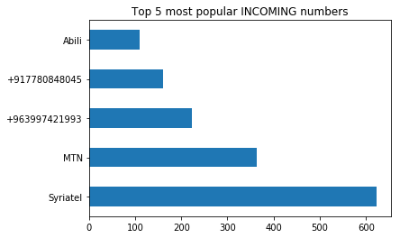

```python
_ = df['call'].value_counts(ascending=True).nlargest(5).plot(kind='barh', title='Top 5 most popular INCOMING numbers')
```

```python
print(most_frequent(incoming['Abili'].remove('null')))
print(most_frequent(incoming['+917780848045']))
print(most_frequent(incoming['+963997421993']))
print(most_frequent(incoming['MTN'].remove('null')))
print(most_frequent(incoming['Syriatel'].remove('null')))
```

```
No name
Musaib Dhurani
هتلر
No name
No name
```

Using the above information and using https://www.searchyellowdirectory.com/reverse-phone for finding the country of the belong number here is the information:

# Top 5 incoming numbers :

1. Syriatel

Name : N/A (showing 'null' because name was not available)

Country : Syria

Number of Calls: 622

1. MTN

Name : N/A (showing 'null' because name was not available)

Country : Syria

Number of Calls: 363

1. +963997421993

Name : هتلر

Country : Syria

Number of Calls: 222

1. +917780848045

Name : Musaib Dhurani

Country : India

Number of Calls: 160

1. Abili

Name : N/A (showing 'null' because name was not available)

Country : Syria

Number of Calls: 110

# Question 4

```python
path = "Isis Admin's Hacked Phones" # Enter Directory of all images
time = {}
time['Yemen'] = []
time['India'] = []
time['Syria'] = []
for root, dirs, files in os.walk(path):
    for name in files:
        if name.startswith(("Calllog Dump")):
            a=root
            a+="/"
            a+=name
            file =a
            with open(file) as f:
                for index, line in enumerate(f):
                    if 'Date	:' in line:
                        line = line.strip('Date	:').strip().split(' ')
#                         print(line)
#                         line = line[3:5]
                        line[4]=line[4].strip('GMT')
                        line[4]=line[4].strip('جرينتش')
                        line = line[1:6]
                        timezone = line[3]
                        line = line[0] +" "+line[1]+" "+line[4]+" "+line[2]
                        line = datetime.datetime.strptime(line, '%b %d %Y %H:%M:%S')
                        timezone = timezone[1:]
                        localtime = line + datetime.timedelta(hours=int(timezone[0:2]),minutes=int(timezone[3:5]))
                        if "Yemen IS (Admins)" in a:
                            time['Yemen'].append(localtime)
                        if "India IS (Admins)" in a:
                            time['India'].append(localtime)
                        if "Syria IS (Admins)" in a:
                            time['Syria'].append(localtime)
            f.close()
```

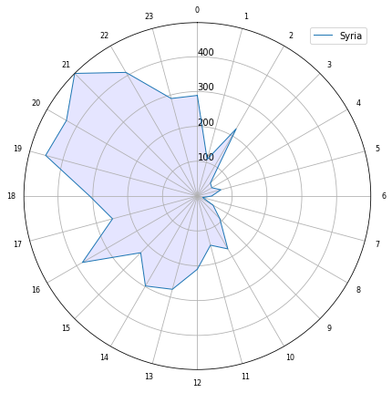

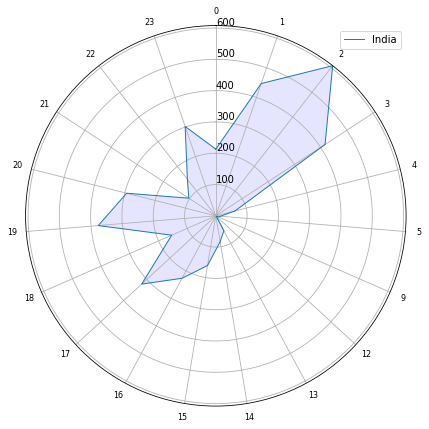

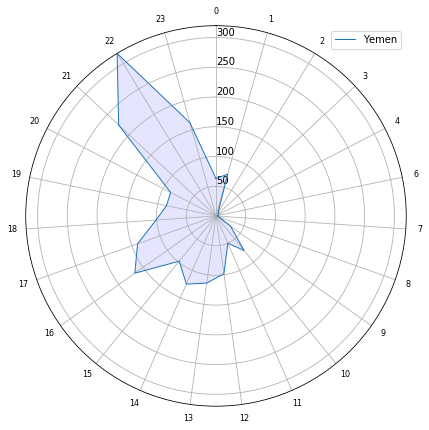

```python
a = []

arrTemp = []
for i in time['Syria']:
    arrTemp.append(i.hour)
temp = {i:arrTemp.count(i) for i in set(arrTemp)}
a.append(temp)

arrTemp = []
for i in time['India']:
    arrTemp.append(i.hour)
temp = {i:arrTemp.count(i) for i in set(arrTemp)}
a.append(temp)

arrTemp = []
for i in time['Yemen']:
    arrTemp.append(i.hour)
temp = {i:arrTemp.count(i) for i in set(arrTemp)}
a.append(temp)

b=['Syria','India','Yemen']
for i in a:
    plt.figure(figsize=(7,7))
    cat = list(i.keys())
    values = list(i.values())
    N = len(cat)
    x_as = [n / float(N) * 2 * pi for n in range(N)]
    values += values[:1]
    x_as += x_as[:1]

    ax = plt.subplot(111, polar=True)

    ax.set_theta_offset(pi / 2)
    ax.set_theta_direction(-1)

    ax.set_rlabel_position(0)
    plt.ylim(0, max(values))

    plt.xticks(x_as[:-1],cat, color='black', size=8)
    ax.plot(x_as, values, linewidth=1, linestyle='solid')
    ax.fill(x_as, values, 'b', alpha=0.1)
    c=a.index(i)
    ax.legend([b[c]])
    plt.show()
```

From the radial plots we could see that the peak call times of all countries **according to their local timezone** are different.

The peak call hours are:

1. Syria : 19 - 22 hrs
2. India : 1-3 hrs
3. Yemen : 21 - 23 hrs

# Question 5

```python
path = "Isis Admin's Hacked Phones"
callduration ={}
for root, dirs, files in os.walk(path):
    for name in files:
        if name.startswith(("Calllog Dump")):
            a=root
            a+="/"
            a+= name
            file =a
            b = file.split('/')
            country=b[1]
            with open(file) as f:
                for index, line in enumerate(f):
                    if 'Duration' in line:
                        duration = line.strip('Duration: ')
                        duration = int(duration)
                        if country in callduration.keys():
                            callduration[country].append(duration)
                        else:
                            callduration[country]=[]
                            callduration[country].append(duration)

            f.close()
average_duration = {}
totalCall = {}
for key,value in callduration.items():
    average_duration[key] = Average(value)
    totalCall[key] = len(value)
```

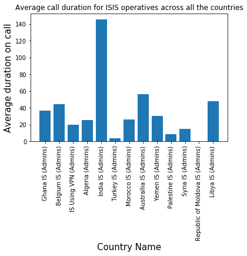

```python
plt.bar(average_duration.keys(), average_duration.values())
plt.xlabel('Country Name', fontsize=15)
plt.ylabel('Average duration on call', fontsize=15)
plt.xticks(rotation=90)
plt.title('Average call duration for ISIS operatives across all the countries')
plt.show()
```

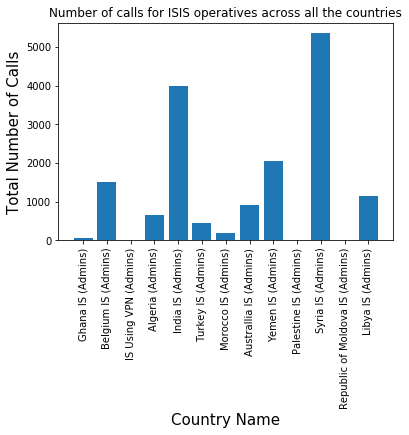

```python
plt.bar(totalCall.keys(), totalCall.values())
plt.xlabel('Country Name', fontsize=15)
plt.ylabel('Total Number of Calls', fontsize=15)
plt.xticks(rotation=90)
plt.title('Number of calls for ISIS operatives across all the countries')
plt.show()
```

```python
totalCall
```

```
{'Ghana IS (Admins)': 50,
 'Belgium IS (Admins)': 1500,
 'IS Using VPN (Admins)': 1,
 'Algeria (Admins)': 669,
 'India IS (Admins)': 3999,
 'Turkey IS (Admins)': 440,
 'Morocco IS (Admins)': 204,
 'Australlia IS (Admins)': 916,
 'Yemen IS (Admins)': 2042,
 'Palestine IS (Admins)': 18,
 'Syria IS (Admins)': 5353,
 'Republic of Moldova IS (Admins)': 2,
 'Libya IS (Admins)': 1151}
```

From the above graphs we could see that India has the highest average duration of calls but does not have highest number of calls.

Republic of Moldova has the lowest average duration of calls but doesn't have the lowest number of calls.

# BONUS

```python
face_cascade = cv2.CascadeClassifier('haarcascade_frontalface_default.xml')
eye_cascade = cv2.CascadeClassifier('haarcascade_eye.xml')
frequency={}
for root, dirs, files in os.walk(path):
    for name in files:
        if name.endswith(("g")):
            a=root
            a+="/"
            a+= name
            file =a
            try:
                img = cv2.imread(a)
                gray = cv2.cvtColor(img, cv2.COLOR_BGR2GRAY)
                b = file.split('/')
                country=b[1]
                face = face_cascade.detectMultiScale(gray, 1.3, 5)
                face = str(face)
                if face in frequency:
                    frequency[face][0]+=1
                else:
                    frequency[face]=[0,0,0]
                    frequency[face][0]=1
                    frequency[face][1]=country
                    frequency[face][2]=a
                cv2.waitKey(0)
                cv2.destroyAllWindows()
            except:
                print(a)
```

```
Isis Admin's Hacked Phones/Belgium IS (Admins)/IS1/Telegram Images/446615094_446329.jpg
Isis Admin's Hacked Phones/Belgium IS (Admins)/IS1/Telegram Images/446529984_447561.jpg
Isis Admin's Hacked Phones/Belgium IS (Admins)/IS1/Telegram Images/446704497_312740.jpg
Isis Admin's Hacked Phones/Belgium IS (Admins)/IS1/Telegram Images/446711860_311596.jpg
Isis Admin's Hacked Phones/Belgium IS (Admins)/IS1/Telegram Images/446618879_445866.jpg
Isis Admin's Hacked Phones/Belgium IS (Admins)/IS1/Telegram Images/446423078_429550.jpg
Isis Admin's Hacked Phones/Belgium IS (Admins)/IS1/Telegram Images/446622572_336026.jpg
Isis Admin's Hacked Phones/Belgium IS (Admins)/IS1/Telegram Images/446535325_445379.jpg.jpg
Isis Admin's Hacked Phones/Belgium IS (Admins)/IS1/Telegram Images/446640176_337795.jpg
Isis Admin's Hacked Phones/Belgium IS (Admins)/IS1/Telegram Images/446411692_446016.jpg
Isis Admin's Hacked Phones/Belgium IS (Admins)/IS1/Telegram Images/446515019_445345.jpg
Isis Admin's Hacked Phones/Belgium IS (Admins)/IS1/Telegram Images/446633840_311263.jpg
Isis Admin's Hacked Phones/Belgium IS (Admins)/IS1/Telegram Images/446638626_338000.jpg
Isis Admin's Hacked Phones/Belgium IS (Admins)/IS1/Telegram Images/446611037_444714.jpg
Isis Admin's Hacked Phones/Belgium IS (Admins)/IS1/Telegram Images/446503551_442245.jpg
Isis Admin's Hacked Phones/Belgium IS (Admins)/IS1/Telegram Images/446722779_310482.jpg
Isis Admin's Hacked Phones/Belgium IS (Admins)/IS1/Telegram Images/446424759_449176.jpg
Isis Admin's Hacked Phones/Belgium IS (Admins)/IS1/Telegram Images/446513283_443700.jpg
Isis Admin's Hacked Phones/Belgium IS (Admins)/IS1/Telegram Images/446502790_447886.jpg
Isis Admin's Hacked Phones/Algeria (Admins)/IS2/ifconfig
Isis Admin's Hacked Phones/Algeria (Admins)/IS1/ifconfig
Isis Admin's Hacked Phones/India IS (Admins)/IS1/Telegram Images/806120198_201974.jpg
Isis Admin's Hacked Phones/Turkey IS (Admins)/IS3/ifconfig
Isis Admin's Hacked Phones/Uganda IS (Admins)/IS1/Whatsapp Images/IMG-20190202-WA0017.jpg
Isis Admin's Hacked Phones/Uganda IS (Admins)/IS1/Telegram Images/806123691_220224.jpg
Isis Admin's Hacked Phones/Yemen IS (Admins)/IS2/Whatsapp Images/IMG-20181105-WA0010.jpg
Isis Admin's Hacked Phones/Yemen IS (Admins)/IS5/Download/IMG_┘в┘а┘б┘и┘а┘ж┘в┘а_┘б┘з┘д┘д┘д┘б.jpg
Isis Admin's Hacked Phones/Syria IS (Admins)/IS3/ifconfig
Isis Admin's Hacked Phones/Syria IS (Admins)/IS3/Telegram Images/806021520_119552.jpg
Isis Admin's Hacked Phones/Libya IS (Admins)/IS1/ifconfig
```

```python
temp = 3
for key, value in frequency.items():
    if value[0] >= temp and value[0] != 2460:
        temp = value[0]
        ans = value
        commonFace = key
        print (ans)
```

```
[3, 'India IS (Admins)', "Isis Admin's Hacked Phones/India IS (Admins)/IS1/Whatsapp Images/Sent/IMG-20180813-WA0014.jpg"]
[3, 'India IS (Admins)', "Isis Admin's Hacked Phones/India IS (Admins)/IS1/Telegram Images/806118275_198739.jpg"]
[3, 'Syria IS (Admins)', "Isis Admin's Hacked Phones/Syria IS (Admins)/IS3/sdcard0_Telegram images/446736002_289763.jpg"]
```

```python
image_path = {}
image_path[commonFace] = []
path2="Isis Admin's Hacked Phones/Syria IS (Admins)/IS3"
for root, dirs, files in os.walk(path2):
    count=0
    for name in files:
        if name.endswith(("jpeg")) or name.endswith(("jpg")):
            a=root
            a+='/'
            a+=name
            try:
                img = cv2.imread(a)
                gray = cv2.cvtColor(img, cv2.COLOR_BGR2GRAY)
                face = face_cascade.detectMultiScale(gray, 1.3, 5)
                face = str(face)
                if face in image_path.keys():
                    image_path[face].append(a)
            except:
                continue
```

```python
image_path
```

```
{'[[199 211 336 336]]': ["Isis Admin's Hacked Phones/Syria IS (Admins)/IS3/sdcard0_Telegram images/446736002_289763.jpg",
  "Isis Admin's Hacked Phones/Syria IS (Admins)/IS3/GBwhatsapp images/Sent/IMG-20181110-WA0059.jpg",
  "Isis Admin's Hacked Phones/Syria IS (Admins)/IS3/Telegram Images/446736002_289763.jpg"]}
```

```python
from IPython.display import Image
Image(filename ="Isis Admin's Hacked Phones/Syria IS (Admins)/IS3/sdcard0_Telegram images/446736002_289763.jpg", width=100, height=100)
```

[output not shown]

```python
Image(filename ="Isis Admin's Hacked Phones/Syria IS (Admins)/IS3/GBwhatsapp images/Sent/IMG-20181110-WA0059.jpg", width=100, height=100)
```

[output not shown]

```python
Image(filename ="Isis Admin's Hacked Phones/Syria IS (Admins)/IS3/Telegram Images/446736002_289763.jpg", width=100, height=100)
```

[output not shown]